# BIOL606_hw_Lecture_08_Hastings

2025-02-19

# Homework Lecture 08

**Question 1:** Pick two of these variables that are not highly correlated. Use binomial glm’s to determine if these factors influence Elaphostrongylus cervi infection in deer.  
- I utilized a correlation matrix to select Fenced and QuercusTrees as the most uncorrelated variables.  
- After checking for over dispersion and getting a deviance ratio of 4.203375, I went back and refit the model using a quasibinomial family.  
- Based on the deer model summary, neither Fenced nor QuercusTrees had a significant effect on the TB infection in deer.  
- Anova output suggested Fenced had some influence but not significantly.

```r
# Load data set.
deer <- read.table('Tbdeer.txt', header = TRUE, sep = '', stringsAsFactors = FALSE) # Load in Tbdeer.txt data set. Prevent the automatic conversion of string values to factors.
glimpse(deer)
```

```
## Rows: 32
## Columns: 15
## $ Farm             <int> 1, 2, 3, 4, 5, 6, 7, 8, 9, 10, 11, 12, 13, 14, 15, 16…
## $ BoarPosTB        <int> 4, 20, 4, 8, 7, 2, 7, 32, 5, 3, 1, 16, 33, 3, 18, 8, …
## $ BoarSampledTB    <int> 14, 34, 5, 13, 23, 20, 21, 62, 25, 3, 7, 18, 41, 9, 3…
## $ DeerPosTB        <int> NA, 3, 0, 1, 0, 2, NA, 5, NA, 6, NA, 11, 28, 1, 0, 1,…
## $ DeerSampledTB    <int> NA, 13, 23, 39, 6, 36, NA, 38, NA, 31, NA, 25, 150, 9…
## $ DeerPosCervi     <int> NA, 6, 28, 39, 13, 19, NA, 8, NA, 30, NA, NA, 76, 2, …
## $ DeerSampledCervi <int> NA, 15, 28, 45, 13, 25, NA, 19, NA, 31, NA, NA, 165, …
## $ OpenLand         <dbl> 0.409, 0.412, 0.182, 0.300, 0.000, 0.286, 0.000, 0.60…
## $ ScrubLand        <dbl> 0.591, 0.059, 0.136, 0.250, 0.571, 0.476, 0.000, 0.35…
## $ QuercusPlants    <dbl> 7.000, 14.706, 5.318, 14.737, 9.333, 21.543, 2.619, 1…
## $ QuercusTrees     <dbl> 1.619, 0.118, 4.045, 4.200, 0.952, 2.972, 1.000, 1.66…
## $ WildBoarIndex    <dbl> 0.095, 0.576, 0.450, 0.100, 0.000, 0.238, 0.025, 1.36…
## $ ReedDeerIndex    <dbl> 0.000, 17.470, 19.412, 6.318, 4.364, 5.141, 0.000, 3.…
## $ EstateSize       <int> 960, 1100, 2200, 1700, 4000, 19328, 3600, 3000, 2000,…
## $ Fenced           <int> 0, 1, 1, 1, 0, 0, 0, 1, 0, 1, 0, 1, 1, 0, 1, 1, 1, 1,…
```

```r
# Check correlation between variables in deer data set.
deer_vars <- deer %>% select(OpenLand, ScrubLand, QuercusPlants, QuercusTrees, EstateSize, Fenced, ReedDeerIndex, WildBoarIndex)

# Compute correlation matrix.
deer_cor_matrix <- cor(deer_vars, use = 'pairwise.complete.obs')

print(deer_cor_matrix)
```

```
##                  OpenLand   ScrubLand QuercusPlants QuercusTrees  EstateSize
## OpenLand       1.00000000  0.09158933    0.20207320   0.04057343 -0.16226426
## ScrubLand      0.09158933  1.00000000    0.03241891  -0.35080821 -0.18220389
## QuercusPlants  0.20207320  0.03241891    1.00000000   0.36885260 -0.06468831
## QuercusTrees   0.04057343 -0.35080821    0.36885260   1.00000000  0.22440921
## EstateSize    -0.16226426 -0.18220389   -0.06468831   0.22440921  1.00000000
## Fenced         0.04184793  0.03924480   -0.04337086   0.02393614 -0.39400085
## ReedDeerIndex  0.10267356 -0.24148535    0.21265621   0.06350088 -0.11105747
## WildBoarIndex  0.07084292  0.09512809    0.12412581   0.06554851 -0.18643899
##                    Fenced ReedDeerIndex WildBoarIndex
## OpenLand       0.04184793    0.10267356    0.07084292
## ScrubLand      0.03924480   -0.24148535    0.09512809
## QuercusPlants -0.04337086    0.21265621    0.12412581
## QuercusTrees   0.02393614    0.06350088    0.06554851
## EstateSize    -0.39400085   -0.11105747   -0.18643899
## Fenced         1.00000000    0.37652056    0.33801805
## ReedDeerIndex  0.37652056    1.00000000    0.55282907
## WildBoarIndex  0.33801805    0.55282907    1.00000000
```

```r
# Remove rows with NA values in DeerPosTB or DeerSampledTB columns.
deer_clean <- deer %>% drop_na(DeerPosTB, DeerSampledTB)

# Create binomial generalized linear model.
# - 'cbind(DeerPosTB, DeerSampledTB - DeerPosTB)' creates a two column response variable of successes 'DeerPosTB' and failures 'DeerSampledTB - DeerPosTB'.
# - Fenced and QuercusTrees are the predictor variables.
bi_deer_model <- glm(cbind(DeerPosTB, DeerSampledTB - DeerPosTB) ~ Fenced + QuercusTrees,
                     data = deer_clean,
                     family = quasibinomial)

# Check for over dispersion.
dev_ratio <- summary(bi_deer_model)$deviance / summary(bi_deer_model)$df.residual
print(dev_ratio)
```

```
## [1] 4.203375
```

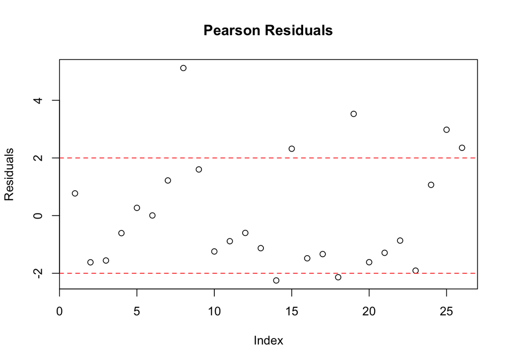

```r
# Check for over dispersion utilizing Pearson residuals.
pearson_resid <- residuals(bi_deer_model, type = 'pearson')
plot(pearson_resid, main = 'Pearson Residuals', ylab = 'Residuals')
abline(h = c(-2, 2), col = 'red', lty = 2)
```

```r
# Summarize bi_deer_model.
summary(bi_deer_model)
```

```
##
## Call:
## glm(formula = cbind(DeerPosTB, DeerSampledTB - DeerPosTB) ~ Fenced +
##     QuercusTrees, family = quasibinomial, data = deer_clean)
##
## Coefficients:
##              Estimate Std. Error t value Pr(>|t|)
## (Intercept)   -2.6765     0.9985  -2.680   0.0134 *
## Fenced         0.9842     0.9297   1.059   0.3008
## QuercusTrees  -0.1185     0.1153  -1.028   0.3147
## ---
## Signif. codes:  0 '***' 0.001 '**' 0.01 '*' 0.05 '.' 0.1 ' ' 1
##
## (Dispersion parameter for quasibinomial family taken to be 4.171578)
##
##     Null deviance: 113.274  on 25  degrees of freedom
## Residual deviance:  96.678  on 23  degrees of freedom
## AIC: NA
##
## Number of Fisher Scoring iterations: 5
```

```r
# Compare fitted model to simpler model.
anova(bi_deer_model, test = 'LRT')
```

```
## Analysis of Deviance Table
##
## Model: quasibinomial, link: logit
##
## Response: cbind(DeerPosTB, DeerSampledTB - DeerPosTB)
##
## Terms added sequentially (first to last)
##
##
##              Df Deviance Resid. Df Resid. Dev Pr(>Chi)
## NULL                            25    113.274
## Fenced        1  11.2883        24    101.986  0.09997 .
## QuercusTrees  1   5.3079        23     96.678  0.25932
## ---
## Signif. codes:  0 '***' 0.001 '**' 0.01 '*' 0.05 '.' 0.1 ' ' 1
```

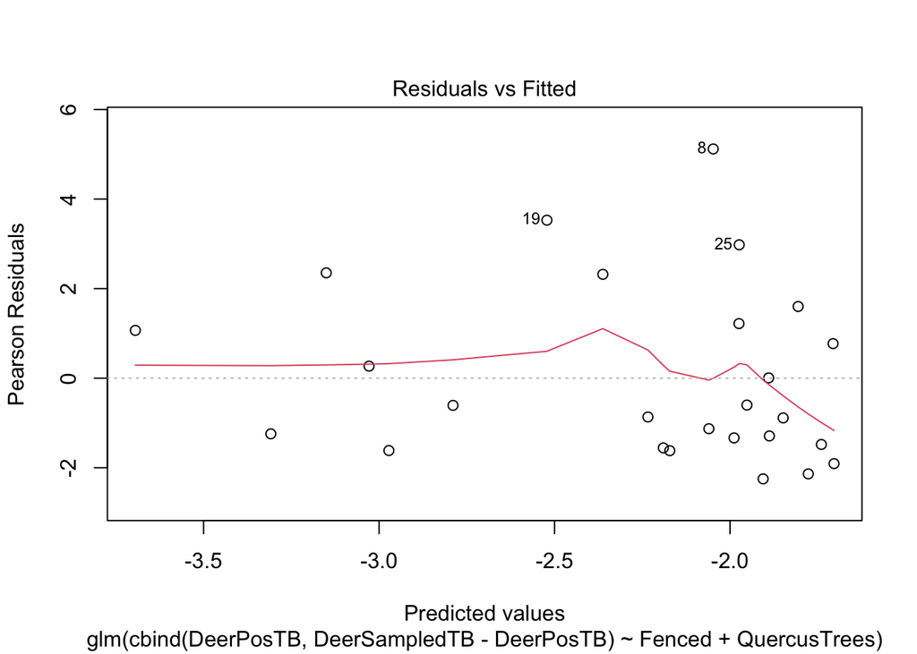

```r
# Check residuals vs. fitted.
plot(bi_deer_model, which = 1)
```

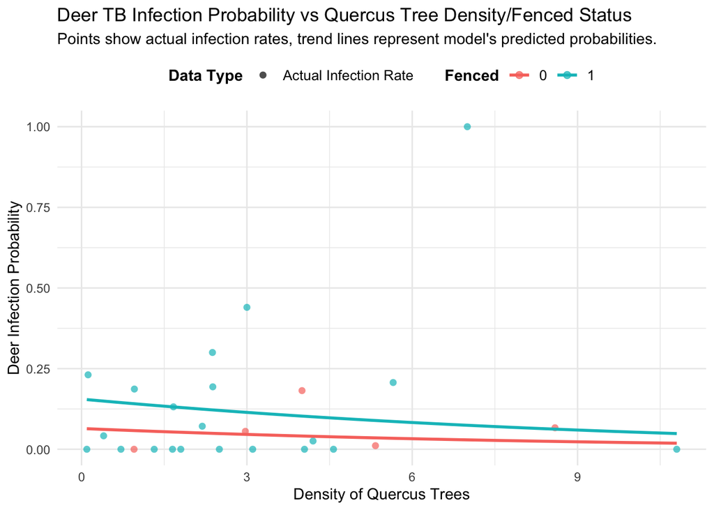

```r
# Create new data frame for generated predicted probabilities using bi_deer_model.
deer_pred <- expand.grid(
  QuercusTrees = seq(min(deer_clean$QuercusTrees), max(deer_clean$QuercusTrees), length.out = 100),
  Fenced = c(0, 1)
)

# Generate predictions (on probability scale).
deer_pred$pred_prob <- predict(bi_deer_model, deer_pred, type = 'response')

# Plot infection probability vs. oak tree density.
deer_model_plot <- ggplot(deer_clean, aes(x = QuercusTrees, y = DeerPosTB / DeerSampledTB, color = as.factor(Fenced))) +
  geom_point(size = 2, alpha = 0.7, aes(shape = 'Actual Infection Rate')) + # Scatter plot of raw data.
  geom_line(data = deer_pred, aes(x = QuercusTrees, y = pred_prob, color = as.factor (Fenced)), linewidth = 1) + # Fitted model predictions.
  labs(
    title = 'Deer TB Infection Probability vs Quercus Tree Density/Fenced Status',
    subtitle = 'Points show actual infection rates, trend lines represent model\'s predicted probabilities.',
    x = 'Density of Quercus Trees',
    y = 'Deer Infection Probability',
    color = 'Fenced',
    shape = 'Data Type',
    linetype = 'Legend') +
  scale_linetype_manual(values = c('Model Prediction' = 'solid')) +
  theme_minimal() +
  theme(
    legend.position = 'top',
    legend.title = element_text(face = 'bold'),
    legend.text = element_text(size = 10)
  )

deer_model_plot
```

**Question 2:** Determine if these same factors affect Tb prevalence in boars.  
- Model summary indicated that Fenced strongly affects the TB prevalence in boars. Anova output also supports this.  
- The Pearson residuals and Residuals vs. Fitted Plot suggest that the boar model performs better than the deer model.

```r
# Load data set.
boar <- read.table('Tbdeer.txt', header = TRUE, sep = '', stringsAsFactors = FALSE) # Load in Tbdeer.txt data set. Prevent the automatic conversion of string values to factors.
glimpse(boar)
```

```
## Rows: 32
## Columns: 15
## $ Farm             <int> 1, 2, 3, 4, 5, 6, 7, 8, 9, 10, 11, 12, 13, 14, 15, 16…
## $ BoarPosTB        <int> 4, 20, 4, 8, 7, 2, 7, 32, 5, 3, 1, 16, 33, 3, 18, 8, …
## $ BoarSampledTB    <int> 14, 34, 5, 13, 23, 20, 21, 62, 25, 3, 7, 18, 41, 9, 3…
## $ DeerPosTB        <int> NA, 3, 0, 1, 0, 2, NA, 5, NA, 6, NA, 11, 28, 1, 0, 1,…
## $ DeerSampledTB    <int> NA, 13, 23, 39, 6, 36, NA, 38, NA, 31, NA, 25, 150, 9…
## $ DeerPosCervi     <int> NA, 6, 28, 39, 13, 19, NA, 8, NA, 30, NA, NA, 76, 2, …
## $ DeerSampledCervi <int> NA, 15, 28, 45, 13, 25, NA, 19, NA, 31, NA, NA, 165, …
## $ OpenLand         <dbl> 0.409, 0.412, 0.182, 0.300, 0.000, 0.286, 0.000, 0.60…
## $ ScrubLand        <dbl> 0.591, 0.059, 0.136, 0.250, 0.571, 0.476, 0.000, 0.35…
## $ QuercusPlants    <dbl> 7.000, 14.706, 5.318, 14.737, 9.333, 21.543, 2.619, 1…
## $ QuercusTrees     <dbl> 1.619, 0.118, 4.045, 4.200, 0.952, 2.972, 1.000, 1.66…
## $ WildBoarIndex    <dbl> 0.095, 0.576, 0.450, 0.100, 0.000, 0.238, 0.025, 1.36…
## $ ReedDeerIndex    <dbl> 0.000, 17.470, 19.412, 6.318, 4.364, 5.141, 0.000, 3.…
## $ EstateSize       <int> 960, 1100, 2200, 1700, 4000, 19328, 3600, 3000, 2000,…
## $ Fenced           <int> 0, 1, 1, 1, 0, 0, 0, 1, 0, 1, 0, 1, 1, 0, 1, 1, 1, 1,…
```

```r
# Remove rows with NA values in BoarPosTB or BoarSampledTB columns.
boar_clean <- deer %>% drop_na(BoarPosTB, BoarSampledTB)

# Create binomial generalized linear model.
bi_boar_model <- glm(cbind(BoarPosTB, BoarSampledTB - BoarPosTB) ~ Fenced + QuercusTrees,
                     data = boar_clean,
                     family = quasibinomial)

# Check for over dispersion.
dev_ratio <- summary(bi_boar_model)$deviance / summary(bi_boar_model)$df.residual
print(dev_ratio)
```

```
## [1] 2.864235
```

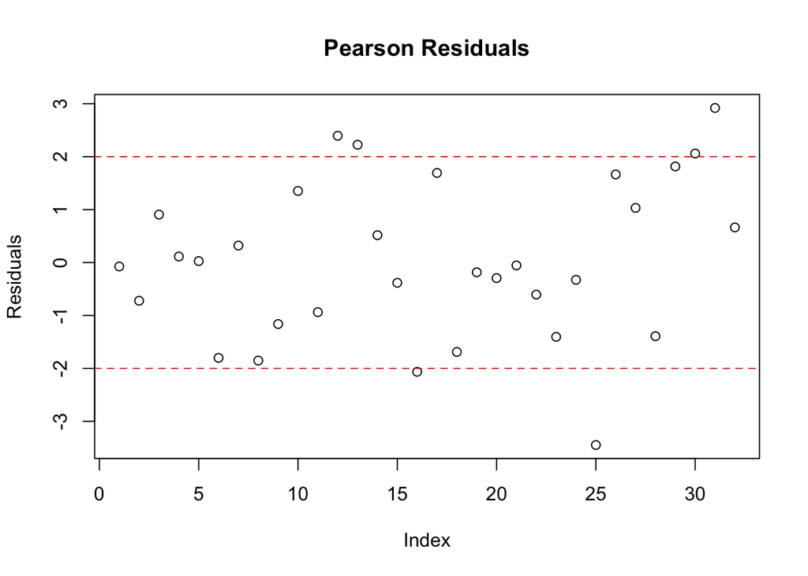

```r
# Check for over dispersion utilizing Pearson residuals.
pearson_resid <- residuals(bi_boar_model, type = 'pearson')
plot(pearson_resid, main = 'Pearson Residuals', ylab = 'Residuals')
abline(h = c(-2, 2), col = 'red', lty = 2)
```

```r
# Summarize bi_boar_model.
summary(bi_boar_model)
```

```
##
## Call:
## glm(formula = cbind(BoarPosTB, BoarSampledTB - BoarPosTB) ~ Fenced +
##     QuercusTrees, family = quasibinomial, data = boar_clean)
##
## Coefficients:
##              Estimate Std. Error t value Pr(>|t|)
## (Intercept)  -0.79173    0.31172  -2.540   0.0167 *
## Fenced        1.40546    0.31150   4.512 9.82e-05 ***
## QuercusTrees -0.04966    0.05032  -0.987   0.3318
## ---
## Signif. codes:  0 '***' 0.001 '**' 0.01 '*' 0.05 '.' 0.1 ' ' 1
##
## (Dispersion parameter for quasibinomial family taken to be 2.413857)
##
##     Null deviance: 141.663  on 31  degrees of freedom
## Residual deviance:  83.063  on 29  degrees of freedom
## AIC: NA
##
## Number of Fisher Scoring iterations: 4
```

```r
# Compare fitted model to simpler model.
anova(bi_boar_model, test = 'LRT')
```

```
## Analysis of Deviance Table
##
## Model: quasibinomial, link: logit
##
## Response: cbind(BoarPosTB, BoarSampledTB - BoarPosTB)
##
## Terms added sequentially (first to last)
##
##
##              Df Deviance Resid. Df Resid. Dev  Pr(>Chi)
## NULL                            31    141.663
## Fenced        1   56.236        30     85.426 1.388e-06 ***
## QuercusTrees  1    2.364        29     83.063    0.3224
## ---
## Signif. codes:  0 '***' 0.001 '**' 0.01 '*' 0.05 '.' 0.1 ' ' 1
```

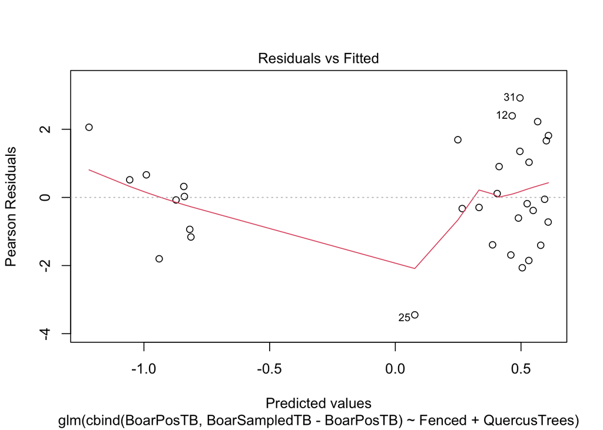

```r
# Check residuals vs. fitted.
plot(bi_boar_model, which = 1)
```

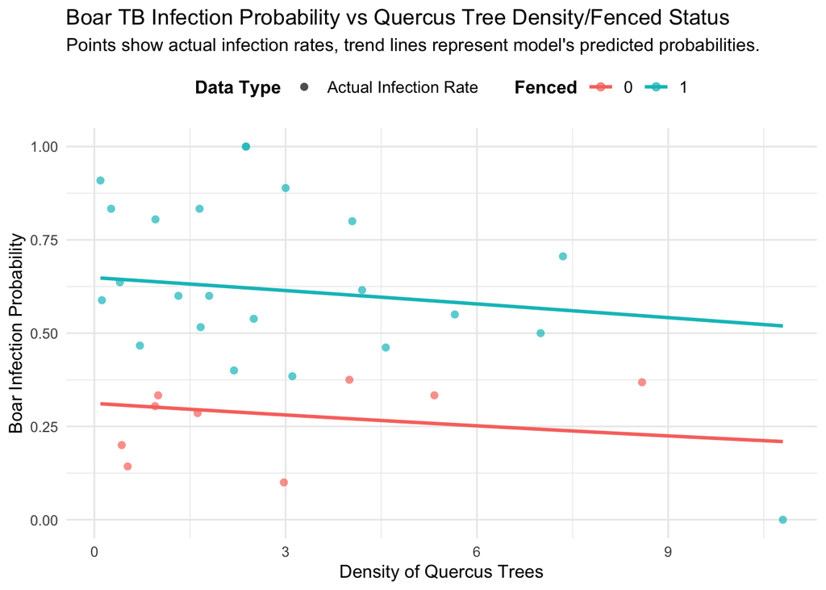

```r
# Create new data frame for generated predicted probabilities using bi_boar_model.
boar_pred <- expand.grid(
  QuercusTrees = seq(min(boar_clean$QuercusTrees), max(boar_clean$QuercusTrees), length.out = 100),
  Fenced = c(0, 1)
)

# Generate predictions (on probability scale).
boar_pred$pred_prob <- predict(bi_boar_model, boar_pred, type = 'response')

# Plot infection probability vs. oak tree density.
boar_model_plot <- ggplot(boar_clean, aes(x = QuercusTrees, y = BoarPosTB / BoarSampledTB, color = as.factor(Fenced))) +
  geom_point(size = 2, alpha = 0.7, aes(shape = 'Actual Infection Rate')) + # Scatter plot of raw data.
  geom_line(data = boar_pred, aes(x = QuercusTrees, y = pred_prob, color = as.factor (Fenced)), linewidth = 1) + # Fitted model predictions.
  labs(
    title = 'Boar TB Infection Probability vs Quercus Tree Density/Fenced Status',
    subtitle = 'Points show actual infection rates, trend lines represent model\'s predicted probabilities.',
    x = 'Density of Quercus Trees',
    y = 'Boar Infection Probability',
    color = 'Fenced',
    shape = 'Data Type',
    linetype = 'Legend') +
  scale_linetype_manual(values = c('Model Prediction' = 'solid')) +
  theme_minimal() +
  theme(
    legend.position = 'top',
    legend.title = element_text(face = 'bold'),
    legend.text = element_text(size = 10)
  )

boar_model_plot
```

**Question 3:** Make figure for each result. (See figures above.) Try to describe what you think it should look like.  
- With the deer model, since the Fenced variable doesn’t have a significant affect on deer infection, the model’s predictive lines should look very similar and be in a similar place on the plot - which they do!  
- With the boar model, since the Fenced variable does have a significant affect on boar infection, the model’s predictive lines for fenced vs unfenced should be different or in different areas of the plot. The fenced predictive line has as significantly higher infection probability which logically make sense. Animals contained together would be more likely to transmit infections to one another.  
**Hajduk & McGill Readings**

```r
## authors: Gabriela K Hajduk, based on workshop developed by Liam Bailey
## contact details: gkhajduk.github.io; email: gkhajduk@gmail.com
## date: 2017-03-09
##

###---- Explore the data -----###

## load the data and have a look at it

load("dragons.RData")

head(dragons)
```

```
##   testScore bodyLength mountainRange site
## 1 16.147309   165.5485      Bavarian    a
## 2 33.886183   167.5593      Bavarian    a
## 3  6.038333   165.8830      Bavarian    a
## 4 18.838821   167.6855      Bavarian    a
## 5 33.862328   169.9597      Bavarian    a
## 6 47.043246   168.6887      Bavarian    a
```

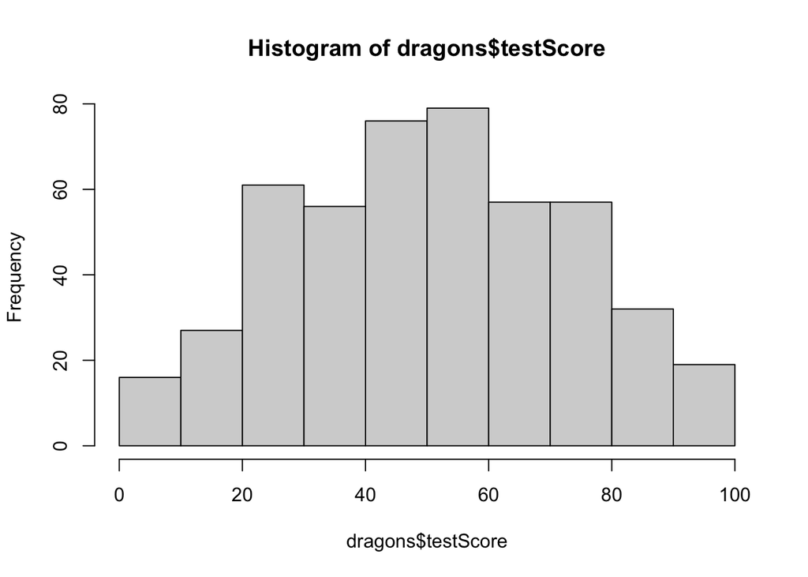

```r
## Let's say we want to know how the body length affects test scores.

## Have a look at the data distribution:

hist(dragons$testScore)  # seems close to normal distribution - good!
```

```r
## It is good practice to standardize your explanatory variables before proceeding - you can use scale() to do that:

dragons$bodyLength2 <- scale(dragons$bodyLength)

## Back to our question: is test score affected by body length?

###---- Fit all data in one analysis -----###

## One way to analyse this data would be to try fitting a linear model to all our data, ignoring the sites and the mountain ranges for now.

library(lme4)
basic.lm <- lm(testScore ~ bodyLength2, data = dragons)

summary(basic.lm)
```

```
##
## Call:
## lm(formula = testScore ~ bodyLength2, data = dragons)
##
## Residuals:
##     Min      1Q  Median      3Q     Max
## -56.962 -16.411  -0.783  15.193  55.200
##
## Coefficients:
##             Estimate Std. Error t value Pr(>|t|)
## (Intercept)  50.3860     0.9676  52.072   <2e-16 ***
## bodyLength2   8.9956     0.9686   9.287   <2e-16 ***
## ---
## Signif. codes:  0 '***' 0.001 '**' 0.01 '*' 0.05 '.' 0.1 ' ' 1
##
## Residual standard error: 21.2 on 478 degrees of freedom
## Multiple R-squared:  0.1529, Adjusted R-squared:  0.1511
## F-statistic: 86.25 on 1 and 478 DF,  p-value: < 2.2e-16
```

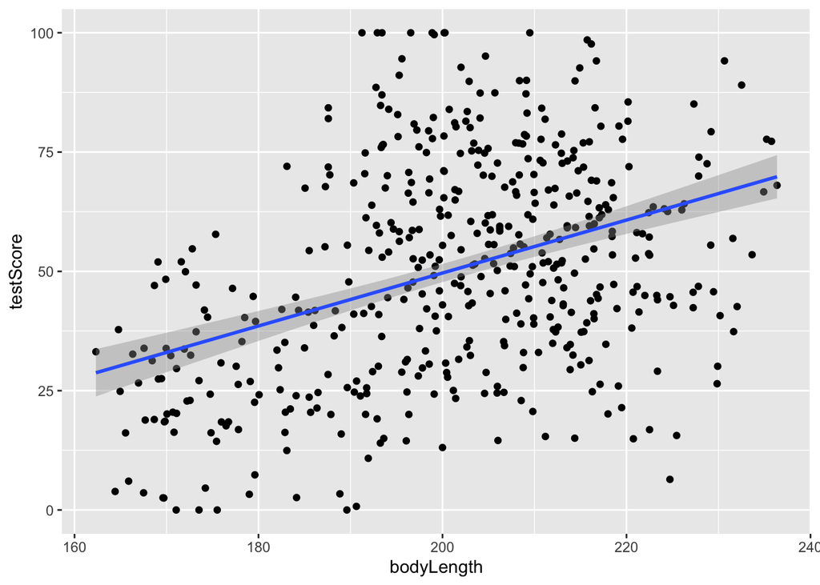

```r
## Let's plot the data with ggplot2

library(ggplot2)

ggplot(dragons, aes(x = bodyLength, y = testScore)) +
  geom_point()+
  geom_smooth(method = "lm")
```

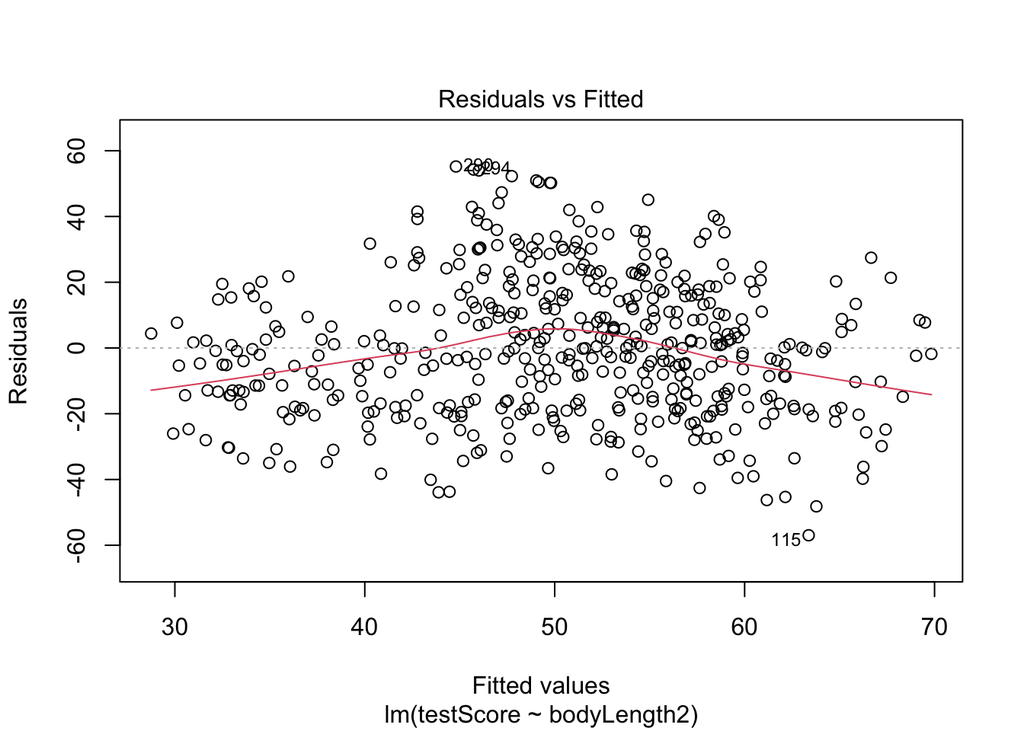

```r
### Assumptions?

## Plot the residuals - the red line should be close to being flat, like the dashed grey line

plot(basic.lm, which = 1)  # not perfect, but look alright
```

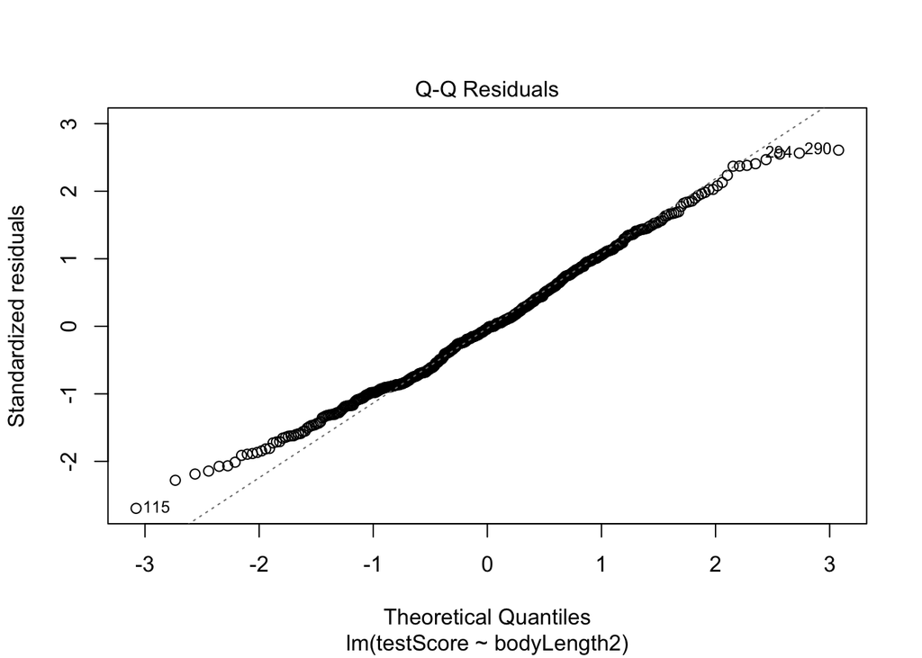

```r
## Have a quick look at the  qqplot too - point should ideally fall onto the diagonal dashed line

plot(basic.lm, which = 2)  # a bit off at the extremes, but that's often the case; again doesn't look too bad
```

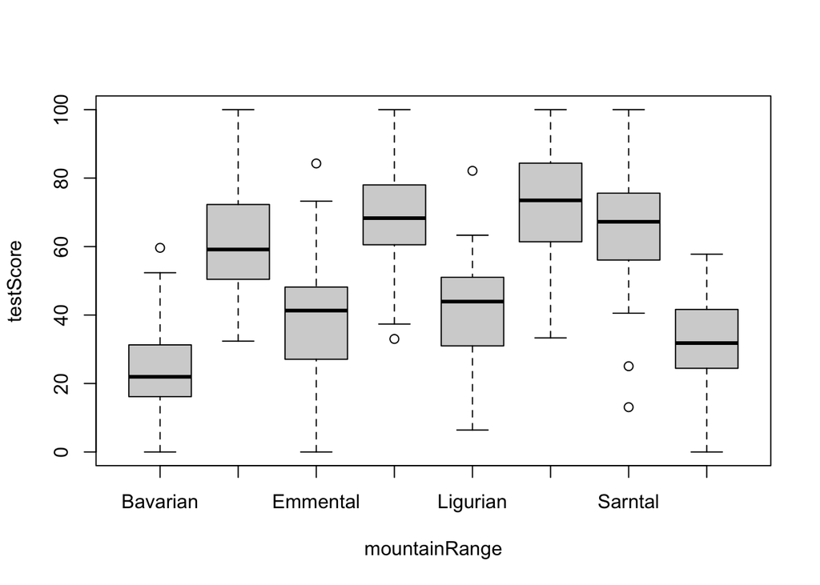

```r
## However, what about observation independence? Are our data independent?
## We collected multiple samples from eight mountain ranges
## It's perfectly plausible that the data from within each mountain range are more similar to each other than the data from different mountain ranges - they are correlated. Pseudoreplication isn't our friend.

## Have a look at the data to see if above is true
boxplot(testScore ~ mountainRange, data = dragons)  # certainly looks like something is going on here
```

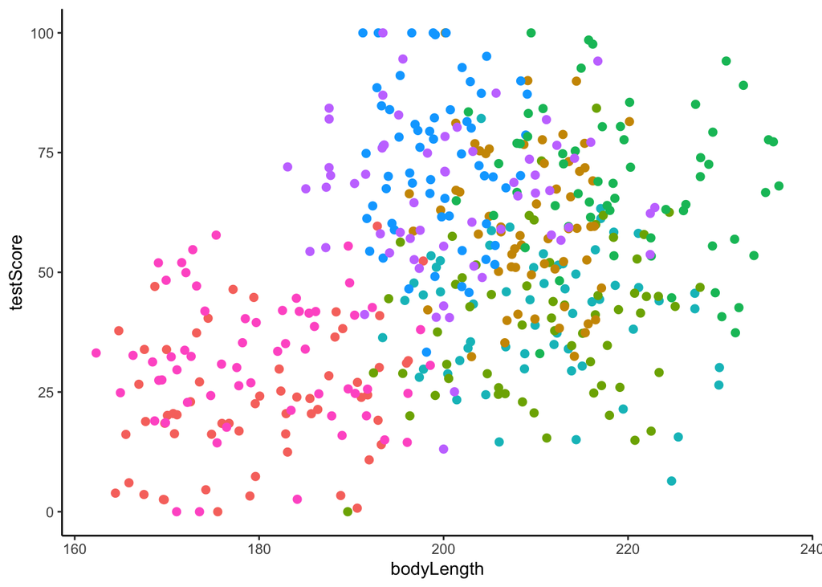

```r
## We could also plot it colouring points by mountain range
ggplot(dragons, aes(x = bodyLength, y = testScore, colour = mountainRange))+
  geom_point(size = 2)+
  theme_classic()+
    theme(legend.position = "none")
```

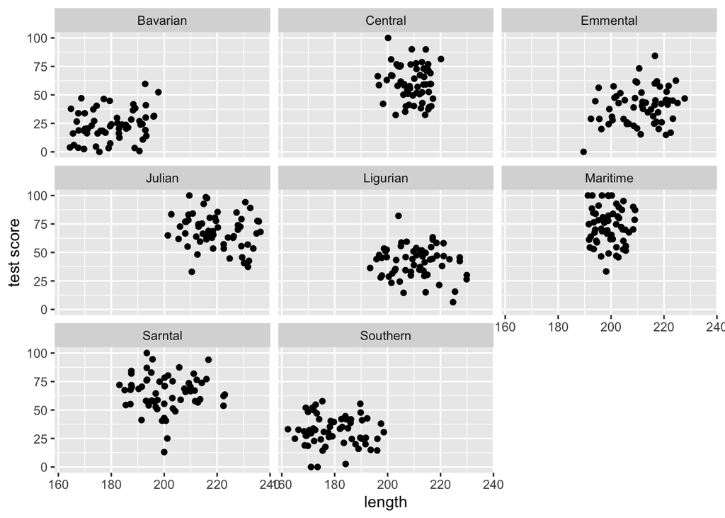

```r
## From the above plots it looks like our mountain ranges vary both in the dragon body length and in their test scores. This confirms that our observations from within each of the ranges aren't independent. We can't ignore that.

## So what do we do?

###----- Run multiple analyses -----###


## We could run many separate analyses and fit a regression for each of the mountain ranges.

## Lets have a quick look at the data split by mountain range
## We use the facet_wrap to do that

ggplot(aes(bodyLength, testScore), data = dragons) + geom_point() +
    facet_wrap(~ mountainRange) +
    xlab("length") + ylab("test score")
```